# Birmingham Air Quality Maps

James Smith

# Birmingham Air Quality

To create maps of annual average air quality (PM2.5 & NO2) for Birmingham we downloaded air quality data from the [DEFRA Local Air Quality Management webpages](https://uk-air.defra.gov.uk/data/laqm-background-maps). Specifically, we downloaded PM2.5 and NO2 data for the regions of ‘Midlands’ and ‘Wales’ for the year 2011, and for the years 2015 to 2030. The 2011 data was downloaded from the 2011 model predictions, and the 2015 to 2030 data was downloaded from the 2015 model predictions. Using these data of regular 1km by 1km pollutant points we then created a raster layer (for every year and pollutant) in the R statistical analysis package. Mean spatially-weighted concentrations for each Birmingham local authority in the study (Cannock Chase, Wolverhampton, Dudley, Sandwell, Tamworth, North Warwickshire, Birmingham, Solihull, Lichfield, Walsall, Bromsgrove, Redditch, Wyre Forest) were then calculated, using the Ward boundaries from the Governments [Open Data portal](http://geoportal.statistics.gov.uk/datasets/wards-december-2016-generalised-clipped-boundaries-in-the-uk).

Now code to sort out the breaks and colour for the maps

## PM2.5 maps

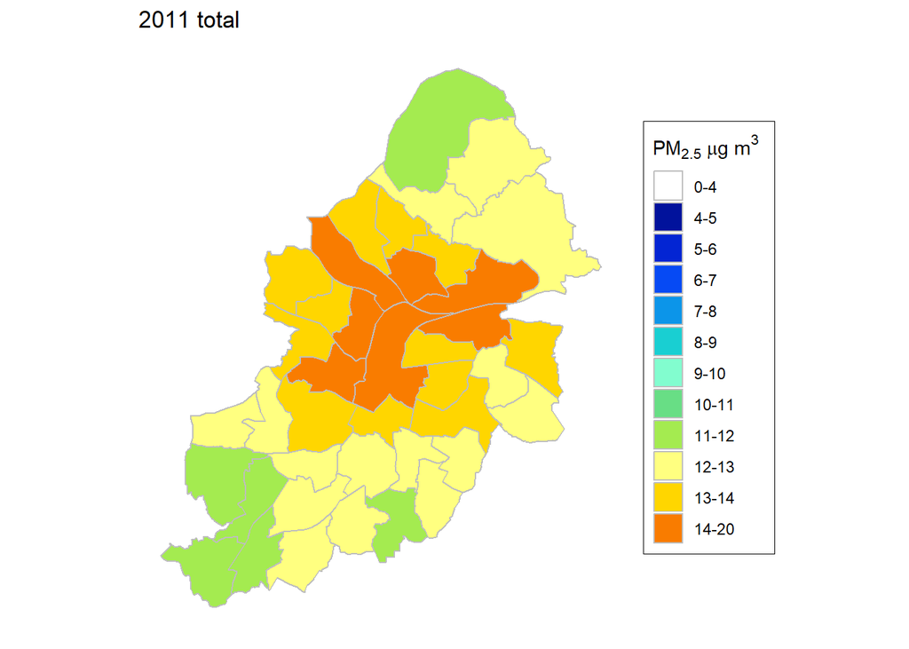

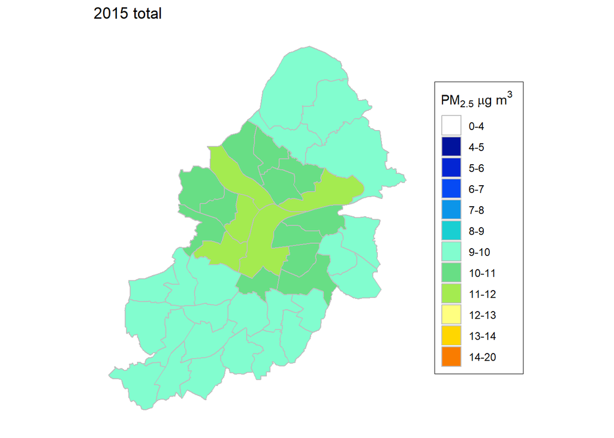

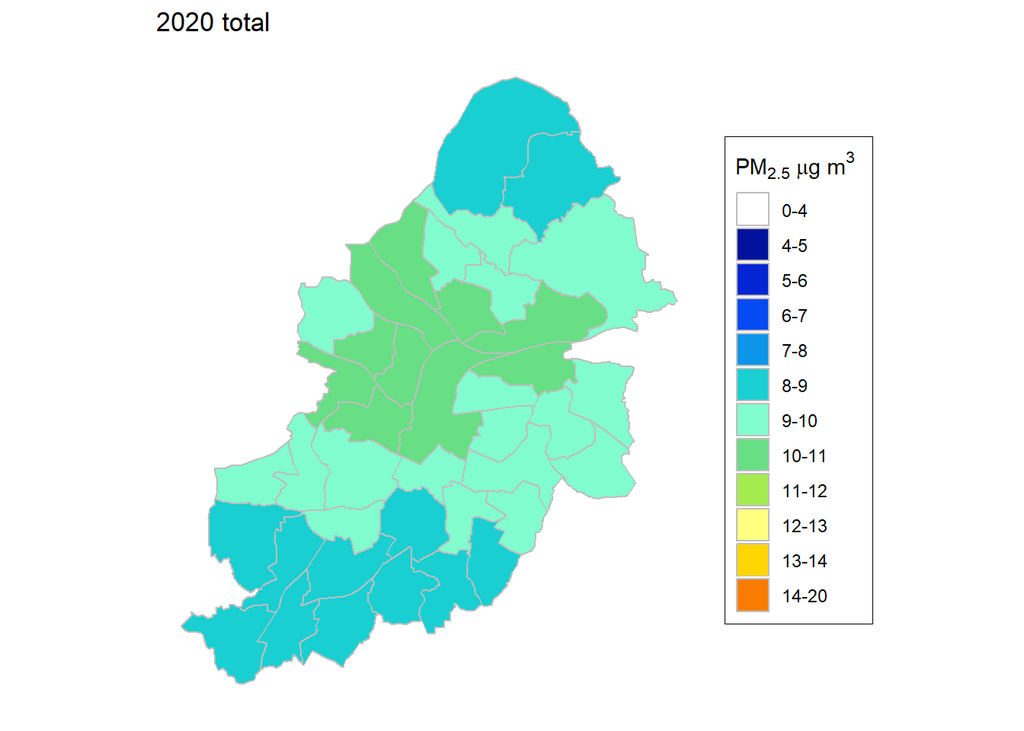

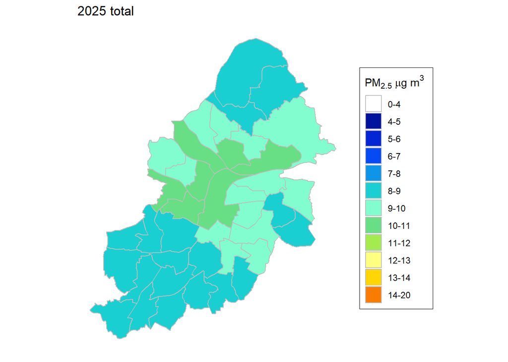

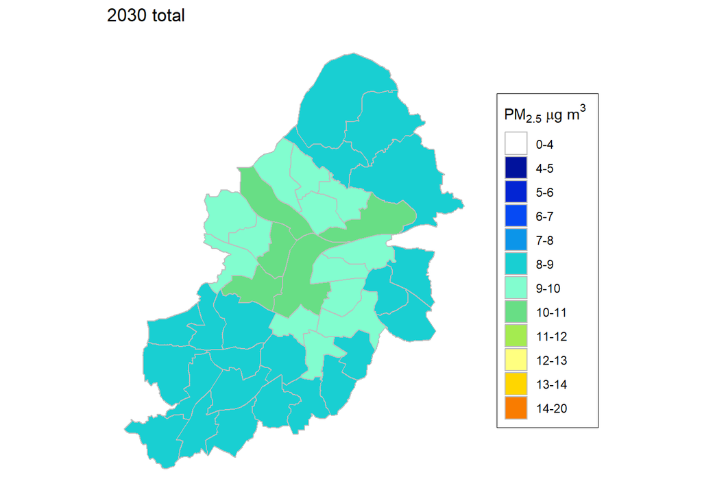

## NO2 maps

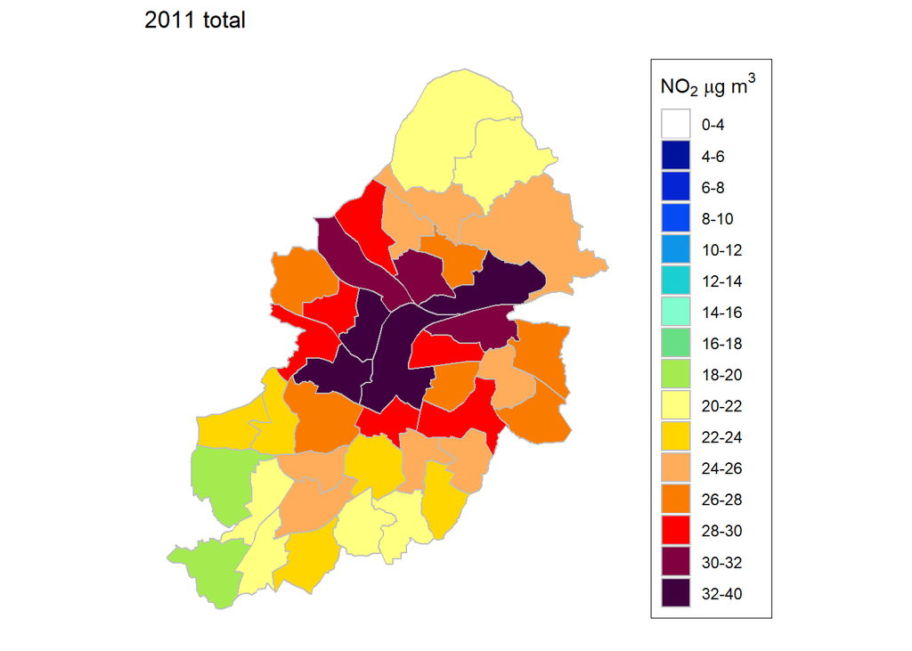

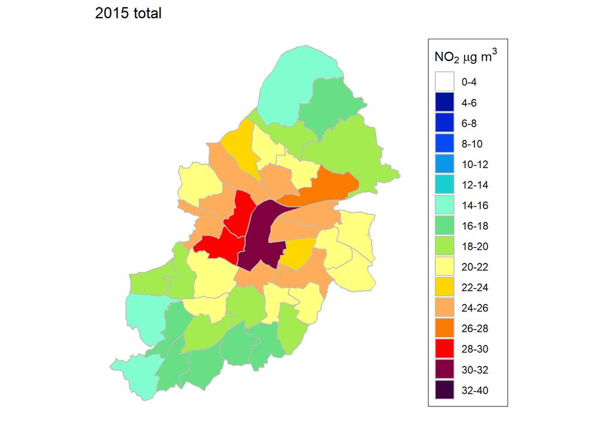

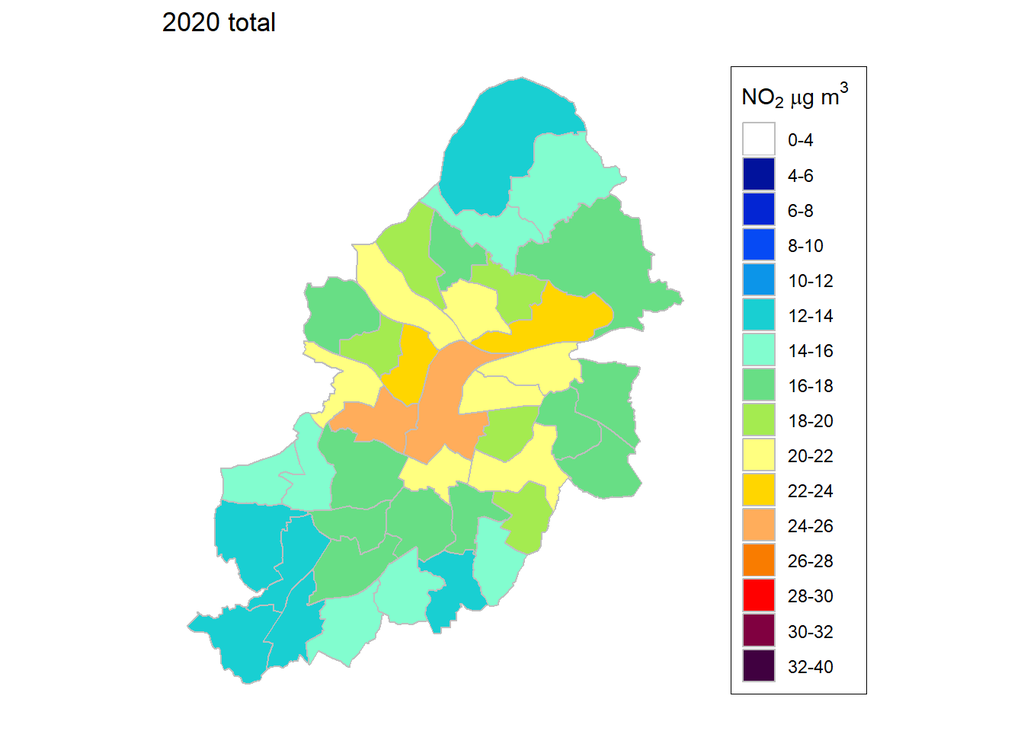

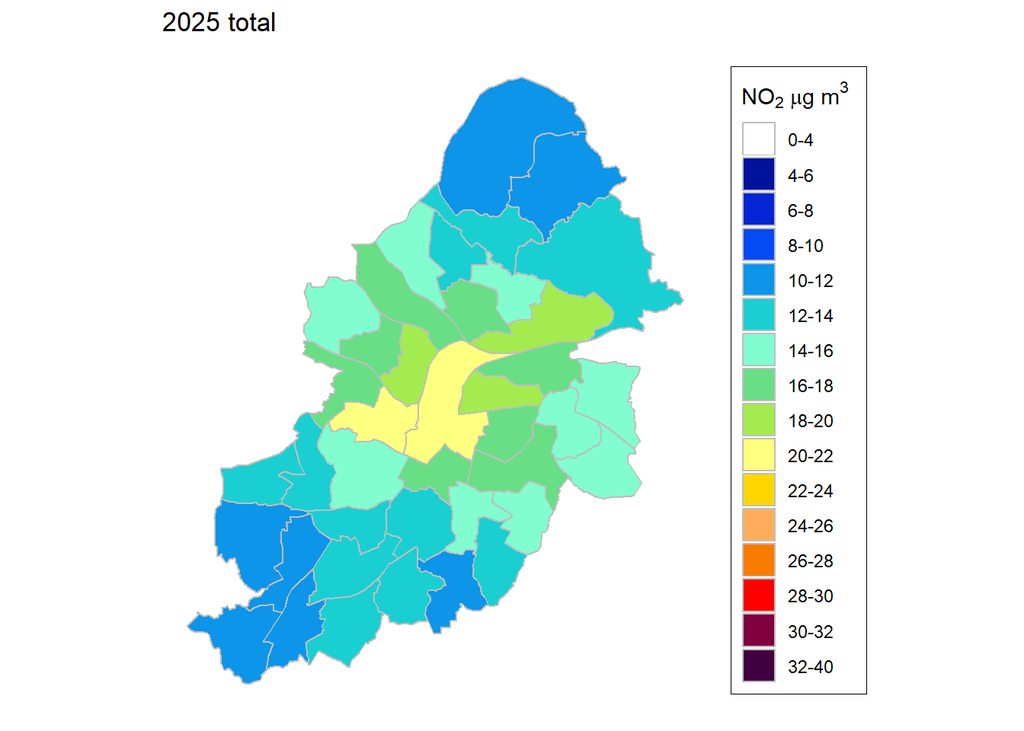

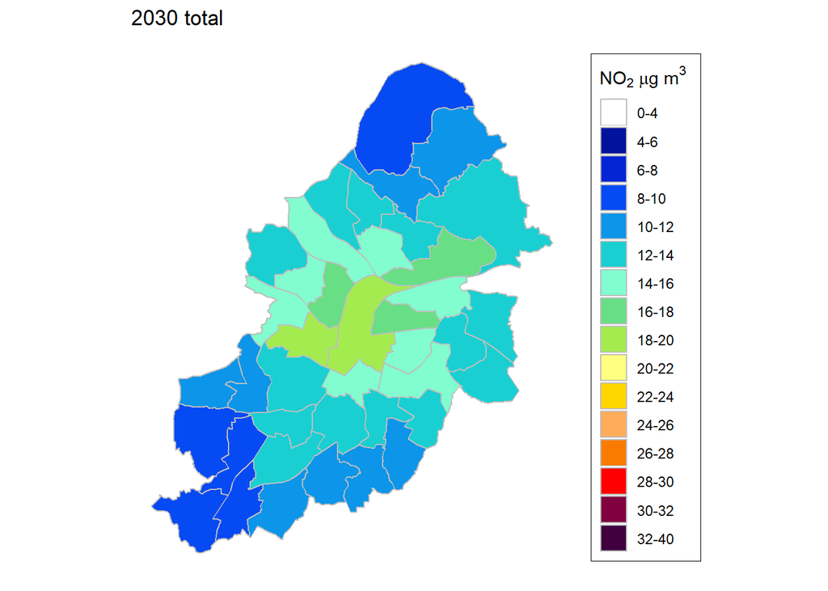

## Map of local authorities

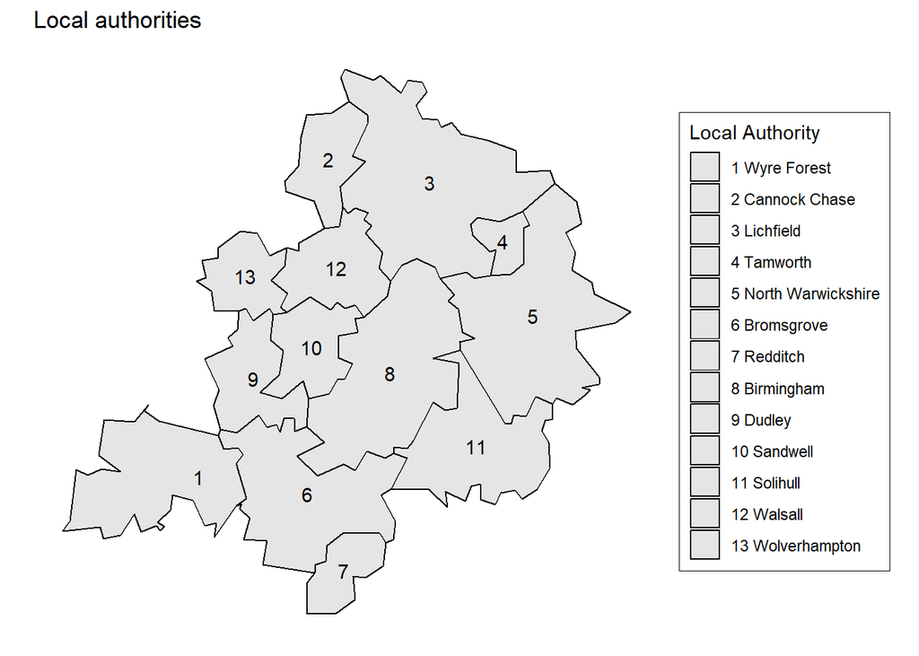